# Pan-Activity in ToxCast/Tox21

Kimberly Truong

2023-09-26

# Data Import and Environment

```r
rm(list=ls())
library(tcpl)
library(RMySQL)
library(data.table)
library(dplyr)
library(ggplot2)
library(ggpubr)

# loads in mc5/sc2 data after some coarse filtering
# long_hitc_final is a long df where every row is a chem x aeid pair and its sc/mc hitcalls
#' @detection_technology_type describes the assay tech
#' @cell_format
load('./data/invitrodb_v3_5_snapshot.RData')
```

# Pull down ToxCast data

```r
# connect to invitrodb with tcpl
tcplConf(user='_dataminer', pass='pass', db='prod_internal_invitrodb_v3_5', drvr='MySQL', host='ccte-mysql-res.epa.gov')

# pull down mc data
mc5 <- tcplPrepOtpt(tcplSubsetChid(tcplLoadData(lvl=5, type = 'mc')))
mc6 <- tcplPrepOtpt(tcplLoadData(lvl=6, fld='m4id', val=mc5$m4id, type='mc'))
setDT(mc6)
mc6_mthds <- mc6[ , .( mc6_mthd_id = paste(mc6_mthd_id, collapse=",")), by = m4id]
mc6_flags <- mc6[ , .( flag = paste(flag, collapse=";")), by = m4id]
mc5$mc6_flags <- mc6_mthds$mc6_mthd_id[match(mc5$m4id, mc6_mthds$m4id)]
mc5[, flag.length := ifelse(!is.na(mc6_flags), count.fields(textConnection(mc6_flags), sep =','), NA)]

# filter the dataset, with coarse filters
mc5[hitc==1 & flag.length < 3, use.me := 1]
mc5[hitc==1 & is.na(flag.length), use.me := 1]
mc5[hitc==1 & flag.length >= 3, use.me := 0]
mc5[fitc %in% c(36,45), use.me := 0]
mc5[hitc==-1, use.me := 0] # data could not be curve-fitted (usually due to having < 4 concs)
mc5[use.me==0, modl_ga := as.numeric(NA)]
mc5[use.me==0, hitc := 0]
mc5[hitc==0, modl_ga := as.numeric(NA)]

setnames(mc5, c('dsstox_substance_id.x'), c('dsstox_substance_id'))
mc5[, dsstox_substance_id.y := NULL]

# pull down sc data
sc2 <- tcplPrepOtpt(tcplSubsetChid(tcplLoadData(lvl=2, type='sc'), type = 'sc')) # for max response and hitcally summary
setnames(sc2, c('dsstox_substance_id.x'), c('dsstox_substance_id'))
sc2[, dsstox_substance_id.y := NULL]

# get hitcall data from sc/mc
long.mc5 <- mc5[!is.na(dsstox_substance_id),
                .(dsstox_substance_id, chnm, aeid, aenm, hitc)]
long.sc2 <- sc2[!is.na(dsstox_substance_id),
                .(dsstox_substance_id, chnm, aeid, aenm, hitc)]

# combine mc/sc data
long_all <- merge.data.table(long.sc2, long.mc5,
                             by = c("dsstox_substance_id", "chnm", "aeid", "aenm"),
                             all = T)
setnames(long_all, old = c("hitc.x", "hitc.y"),
         new = c("sc.hitc", "mc.hitc"))

# if tested in both, take hitc from mc; otherwise, take hitc from sc
long_hitc_final <- long_all %>%
  rowwise() %>%
  mutate(hitc = ifelse(!is.na(mc.hitc), mc.hitc, sc.hitc))

setDT(long_hitc_final)
```

```r
length(unique(long_hitc_final$aenm)) # 2228 unique endpoints in ToxCast/Tox21
```

```
## [1] 2228
```

```r
length(unique(long_hitc_final$dsstox_substance_id)) # 9541 unique chems
```

```
## [1] 9541
```

- 9541 unique chemicals
- 2228 total unique endpoints

# Are colorful substances pan-actors?

## compute hit rates

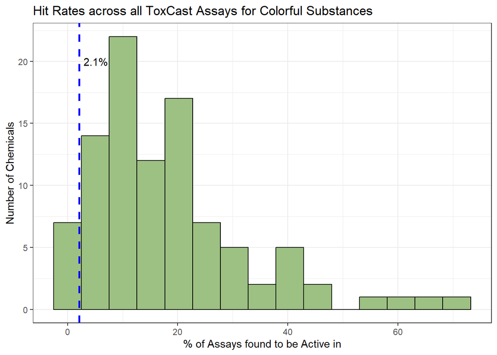

```r
# by chemical hit-rate
# lw(x) == length(which(x))
hit.rates <- long_hitc_final[, list(
  total.cnt  = .N, #total number of aeids tested for that chem (sc and/or mc)
  active.cnt  = as.double(lw(hitc==1)),  # active count
  inactive.cnt  = as.double(lw(hitc==0)),  #inactive count
  active.pct = (lw(hitc==1)/.N)*100, #active percent
  inactive.pct = (lw(hitc==0)/.N)*100 #inactive percent
), by = list(chnm, dsstox_substance_id)]

# capture all colored chems
color.chnms <- hit.rates$chnm[grep("\\w+\\s(red|orange|yellow|green|blue|violet|black)\\s*\\w*", hit.rates$chnm, ignore.case = T)]
ci <- hit.rates$chnm[grep("C.I.", hit.rates$chnm)] # important to capture  substances like "C.I. Azoic Diazo Component 112"
fdc <- hit.rates$chnm[grep("^[F]*D&C", hit.rates$chnm)]
all.colors.nm <- purrr::reduce(list(color.chnms, ci, fdc), union) # 97 chems

hit.rates.colors <- hit.rates[chnm %in% all.colors.nm, ]

ggplot(hit.rates.colors, aes(x=active.pct)) +
  geom_histogram(color="black", fill="#9DC183", bins = 15) +
  geom_vline(aes(xintercept=median(hit.rates$active.pct)),
             color="blue", linetype="dashed", linewidth=1) +
  annotate(geom = "text", x = median(hit.rates$active.pct) + 3, y = 20,
           label = paste0(round(median(hit.rates$active.pct), 1), "%")) +
  ggtitle('Hit Rates across all ToxCast Assays for Colorful Substances') +
  xlab('% of Assays found to be Active in') + ylab('Number of Chemicals') +
  theme_bw()
```

## what chemicals hit at least 30% of ToxCast assays?

```r
hit.rates.colors[active.pct >= 30][order(-active.pct)]
```

| chnm | dsstox_substance_id | total.cnt | active.cnt | inactive.cnt | active.pct | inactive.pct |
| --- | --- | --- | --- | --- | --- | --- |
| Malachite green oxalate | DTXSID6025513 | 235 | 166 | 69 | 70.63830 | 29.36170 |
| C.I. Solvent Black 5 | DTXSID0026040 | 235 | 152 | 83 | 64.68085 | 35.31915 |
| Brilliant Green | DTXSID1048700 | 79 | 46 | 33 | 58.22785 | 41.77215 |
| C.I. Basic Violet 1 | DTXSID8046666 | 86 | 49 | 37 | 56.97674 | 43.02326 |
| C.I. Oxidation Base 12A | DTXSID7020398 | 235 | 107 | 128 | 45.53191 | 54.46809 |
| Basic Blue 7 | DTXSID5038888 | 727 | 331 | 396 | 45.52957 | 54.47043 |
| Methylene Blue trihydrate | DTXSID0025600 | 235 | 99 | 136 | 42.12766 | 57.87234 |
| Gentian Violet | DTXSID5020653 | 1262 | 512 | 750 | 40.57052 | 59.42948 |
| C.I. 1040 | DTXSID8048945 | 235 | 93 | 142 | 39.57447 | 60.42553 |
| Malachite green | DTXSID1025512 | 568 | 217 | 351 | 38.20423 | 61.79577 |

[output cut: 5 more lines]

```r
length(unique(hit.rates.colors[active.pct >= 30]$dsstox_substance_id))
```

```
## [1] 15
```

## pull down assay meta data

```r
# connect to invitrodb for RMySQL connection
con <- dbConnect(drv = RMySQL::MySQL(), user="ktruong", #fill user
                 password = "Today061822K!!", # fill pass
                 host = "ccte-mysql-res.epa.gov", database = prod_internal_invitrodb_v3_5)

assays <- dbGetQuery(con, "SELECT * FROM prod_internal_invitrodb_v3_5.assay
INNER JOIN prod_internal_invitrodb_v3_5.assay_component ON assay.aid=assay_component.aid
INNER JOIN prod_internal_invitrodb_v3_5.assay_component_endpoint ON assay_component.acid=assay_component_endpoint.acid;")
long_hitc_final$detection_technology_type <- assays$detection_technology_type[match(long_hitc_final$aeid, assays$aeid)]
```

## looking at just spectrophotometric assays

```r
sp.assays <- long_hitc_final[detection_technology_type %in% c("Spectrophotometry", "spectrophotometry",
                                                  "Absorbance ", "Colorimetric")]

length(unique(sp.assays$aeid)) # 93 relevant colorimetric endpoints
```

```
## [1] 93
```

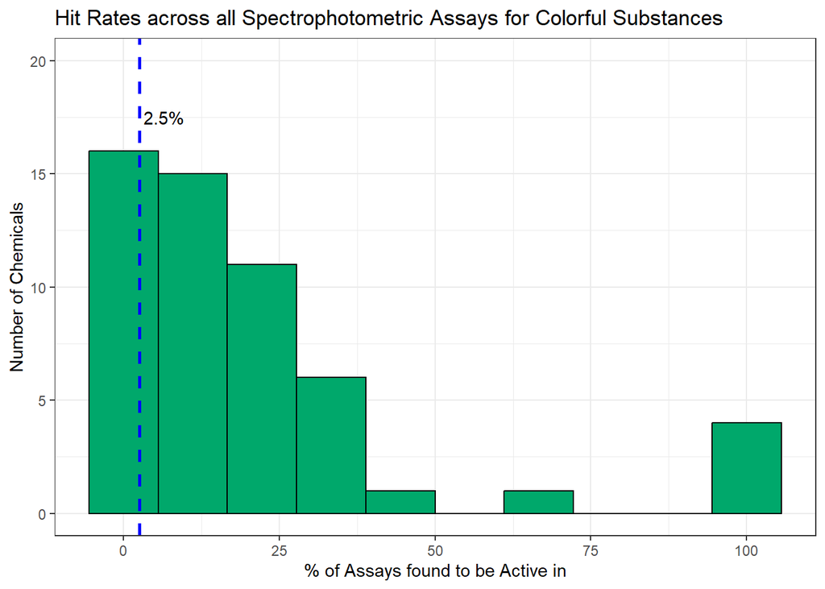

```r
hitrates.sp <- sp.assays[, list(
  total.cnt  = .N, #total number of aeids tested for each chem
  active.cnt  = as.double(lw(hitc==1)),  # active count
  inactive.cnt  = as.double(lw(hitc==0)),  #inactive count
  active.pct = (lw(hitc==1)/.N)*100, #active percent
  inactive.pct = (lw(hitc==0)/.N)*100 #inactive percent
), by = list(chnm, dsstox_substance_id)]

colors.data <- hitrates.sp[chnm %in% all.colors.nm, ]

ggplot(colors.data, aes(x=active.pct)) +
  geom_histogram(color="black", fill="#00A86B", bins = 10) +
  geom_vline(aes(xintercept=median(hitrates.sp$active.pct)),
             color="blue", linetype="dashed", linewidth=1) +
  annotate(geom = "text", x = median(hitrates.sp$active.pct) + 4, y = 17.5,
           label = paste0(median(hitrates.sp$active.pct), "%")) +
  ylim(0, 20) +
  ggtitle('Hit Rates across all Spectrophotometric Assays for Colorful Substances') +
  xlab('% of Assays found to be Active in') + ylab('Number of Chemicals') +
  theme_bw()
```

## what are the chemicals that hit 100% of spectrophotometric assays?

```r
colors.data[active.pct == 100]
```

| chnm | dsstox_substance_id | total.cnt | active.cnt | inactive.cnt | active.pct | inactive.pct |
| --- | --- | --- | --- | --- | --- | --- |
| FD&C Green No. 3 | DTXSID3020673 | 4 | 4 | 0 | 100 | 0 |
| C.I. Direct Yellow 12 | DTXSID5041728 | 3 | 3 | 0 | 100 | 0 |
| Bromophenol blue | DTXSID6041682 | 4 | 4 | 0 | 100 | 0 |
| C.I. Acid Red 114 | DTXSID8021224 | 1 | 1 | 0 | 100 | 0 |

- FD&C Green No. 3 and Bromophenol Blue were found to be “active” for DIO1,2,3 and IYD targets.
- C.I. Direct Yellow 12 was found to be active for DIO 1-3.
- C.I. Acid Red 114 was only tested for IYD and was found to be active.

## what are the chemicals that hit at least 30% of spectrophotometric assays?

```r
colors.data[active.pct > 30 & active.pct <= 100]
```

| chnm | dsstox_substance_id | total.cnt | active.cnt | inactive.cnt | active.pct | inactive.pct |
| --- | --- | --- | --- | --- | --- | --- |
| FD&C Green No. 3 | DTXSID3020673 | 4 | 4 | 0 | 100.00000 | 0.00000 |
| Gentian Violet | DTXSID5020653 | 66 | 23 | 43 | 34.84848 | 65.15152 |
| C.I. Direct Yellow 12 | DTXSID5041728 | 3 | 3 | 0 | 100.00000 | 0.00000 |
| Bromophenol blue | DTXSID6041682 | 4 | 4 | 0 | 100.00000 | 0.00000 |
| C.I. Acid Orange 24, monosodium salt | DTXSID7041708 | 3 | 2 | 1 | 66.66667 | 33.33333 |
| C.I. Acid Orange 156 | DTXSID7044718 | 26 | 8 | 18 | 30.76923 | 69.23077 |
| C.I. Acid Red 114 | DTXSID8021224 | 1 | 1 | 0 | 100.00000 | 0.00000 |
| Phenol red | DTXSID8022408 | 4 | 2 | 2 | 50.00000 | 50.00000 |
| C.I. Acid Red 1 | DTXSID9044663 | 3 | 1 | 2 | 33.33333 | 66.66667 |

## what are the chemicals that do not hit any of the spectrophotometric assays?

```r
colors.data[active.pct == 0]
```

| chnm | dsstox_substance_id | total.cnt | active.cnt | inactive.cnt | active.pct | inactive.pct |
| --- | --- | --- | --- | --- | --- | --- |
| C.I. Acid Blue 74 | DTXSID1020190 | 22 | 0 | 22 | 0 | 100 |
| Methyl red | DTXSID1042154 | 24 | 0 | 24 | 0 | 100 |
| FD&C Red 4 | DTXSID2021234 | 3 | 0 | 3 | 0 | 100 |
| C.I. Disperse Red 60 | DTXSID2025210 | 54 | 0 | 54 | 0 | 100 |
| Sulfan blue | DTXSID3026065 | 24 | 0 | 24 | 0 | 100 |
| C.I. Acid Yellow 11, sodium salt | DTXSID5047451 | 24 | 0 | 24 | 0 | 100 |
| C.I. Acid Orange 10 | DTXSID6021082 | 4 | 0 | 4 | 0 | 100 |
| p-Xylenol blue | DTXSID8026303 | 25 | 0 | 25 | 0 | 100 |
| D&C Blue No. 9 | DTXSID9044532 | 35 | 0 | 35 | 0 | 100 |

## colorful substances are not tested uniformly

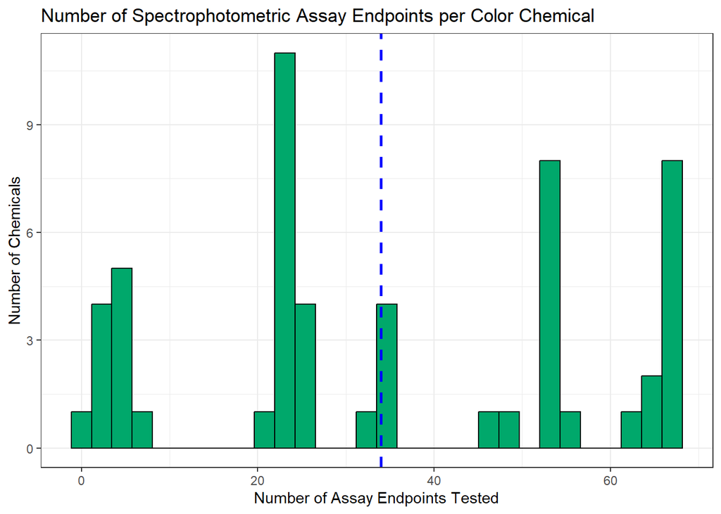

```r
ggplot(colors.data, aes(x=total.cnt)) +
  geom_histogram(color="black", fill="#00A86B") +
  geom_vline(aes(xintercept=median(hitrates.sp$total.cnt)),
             color="blue", linetype="dashed", linewidth=1) +
  ggtitle('Number of Spectrophotometric Assay Endpoints per Color Chemical') +
  xlab('Number of Assay Endpoints Tested') +
  ylab('Number of Chemicals') +
  theme_bw()
```

## create RData

```r
save(mc5,
     sc2,
     long_hitc_final,
     file = "./data/invitrodb_v3_5_snapshot.RData")

# save all chems in ToxCast library to get ToxPrints
lib <- data.frame(DTXSID = hit.rates$dsstox_substance_id)
write.csv(lib, "./data/ToxCast_all_chems_invitrodb_v3_5.csv", row.names = F)
```

# What about long-chain carbons?

## load ToxPrints

```r
toxprints <- fread("./data/ToxCast_invitrodb_v3_5_toxprints.csv")

length(unique(toxprints$DTXSID))
```

```
## [1] 8909
```

- 8909 out of the 9541 chemicals in ToxCast/Tox21 library can be mapped to the ToxPrint space.

## pan-active chemotypes

We wish to investigate whether chemicals with chemotypes found to be significantly enriched across the DIO/IYD assays may be pan-active across all protein-based/cell-free assays found in ToxCast/Tox21.

```r
long_hitc_final$cell_format <- assays$cell_format[match(long_hitc_final$aeid, assays$aeid)]

# these are overlapping chem sets
c8 <- toxprints[`chain:alkaneLinear_octyl_C8` == 1, DTXSID]
c10 <- toxprints[`chain:alkaneLinear_decyl_C10` == 1, DTXSID]
c12 <- toxprints[`chain:alkaneLinear_dodedyl_C12` == 1, DTXSID]
c14 <- toxprints[`chain:alkaneLinear_tetradecyl_C14` == 1, DTXSID]
all.chains <- Reduce(union, list(c8, c10, c12, c14))

length(unique(all.chains))
```

```
## [1] 391
```

- There are 391 unique chemicals found in the ToxCast/Tox21 library that had at least one of these chemotypes:
  - chain:alkaneLinear_octyl_C8
  - chain:alkaneLinear_decyl_C10
  - chain:alkaneLinear_dodedyl_C12
  - chain:alkaneLinear_tetradecyl_C14

## compute hit rates in different sets of assays

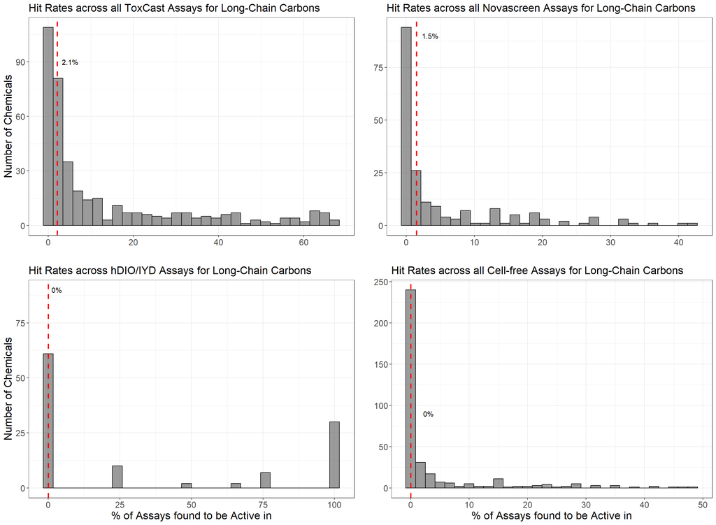

```r
tc.longchainc.data <- hit.rates[dsstox_substance_id %in% all.chains]

# describe each chem by its largest carbon length
tc.longchainc.data[dsstox_substance_id %in% c8, carbon_length := "C8"]
tc.longchainc.data[dsstox_substance_id %in% c10, carbon_length := "C10"]
tc.longchainc.data[dsstox_substance_id %in% c12, carbon_length := "C12"]
tc.longchainc.data[dsstox_substance_id %in% c14, carbon_length := "C14"]

# hit rates across all ToxCast assays for just these carbon chains
tc.gg <- ggplot(tc.longchainc.data, aes(x=active.pct)) +
  geom_histogram(color="black", alpha = 0.6) +
  geom_vline(aes(xintercept=median(hit.rates$active.pct)),
             color="red", linetype="dashed", linewidth=1) +
  annotate(geom = "text", x = median(hit.rates$active.pct) + 3, y = 90,
           label = paste0(round(median(hit.rates$active.pct), 1), "%")) +
  ggtitle('Hit Rates across all ToxCast Assays for Long-Chain Carbons') +
  xlab('% of Assays found to be Active in') + ylab('Number of Chemicals') +
  theme_bw() +
  theme(plot.title = element_text(size = 16),
        axis.title.x = element_text(size = 16),
        axis.title.y = element_text(size = 16),
        axis.text.x = element_text(size = 13),
        axis.text.y = element_text(size = 13))

# compute hit rates in only Novascreen Assays
nvs.data <- long_hitc_final[grep("^NVS", long_hitc_final$aenm), ]

hitrates.nvs <- nvs.data[, list(
  total.cnt  = .N, #total number of aeids tested for each chem
  active.cnt  = as.double(lw(hitc==1)),  # active count
  inactive.cnt  = as.double(lw(hitc==0)),  #inactive count
  active.pct = (lw(hitc==1)/.N)*100, #active percent
  inactive.pct = (lw(hitc==0)/.N)*100 #inactive percent
), by = list(chnm, dsstox_substance_id)]

nvs.longchainc.data <- hitrates.nvs[dsstox_substance_id %in% all.chains]

nvs.gg <- ggplot(nvs.longchainc.data, aes(x=active.pct)) +
  geom_histogram(color="black", alpha = 0.6) +
  geom_vline(aes(xintercept=median(hitrates.nvs$active.pct)),
             color="red", linetype="dashed", linewidth=1) +
  annotate(geom = "text", x = median(hitrates.nvs$active.pct) + 2, y = 90,
           label = paste0(round(median(hitrates.nvs$active.pct), 1), "%")) +
  ggtitle('Hit Rates across all Novascreen Assays for Long-Chain Carbons') +
  xlab('% of Assays found to be Active in') + ylab('Number of Chemicals') +
  theme_bw() +
  theme(plot.title = element_text(size = 16),
      axis.title.x = element_text(size = 16),
      axis.title.y = element_text(size = 16),
      axis.text.x = element_text(size = 13),
      axis.text.y = element_text(size = 13))


# compute hit rates in just the deiodinase assays
deiod.data <- long_hitc_final[grep("\\w+h(DIO|IYD)\\w+", long_hitc_final$aenm), ]

hitrates.deiod <- deiod.data[, list(
  total.cnt  = .N, #total number of aeids tested for each chem
  active.cnt  = as.double(lw(hitc==1)),  # active count
  inactive.cnt  = as.double(lw(hitc==0)),  #inactive count
  active.pct = (lw(hitc==1)/.N)*100, #active percent
  inactive.pct = (lw(hitc==0)/.N)*100 #inactive percent
), by = list(chnm, dsstox_substance_id)]

deiod.longchainc.data <- hitrates.deiod[dsstox_substance_id %in% all.chains]

deiod.gg <- ggplot(deiod.longchainc.data, aes(x=active.pct)) +
  geom_histogram(color="black", alpha = 0.6) +
  geom_vline(aes(xintercept=median(hitrates.deiod$active.pct)),
             color="red", linetype="dashed", linewidth=1) +
  annotate(geom = "text", x = median(hitrates.deiod$active.pct) + 3, y = 90,
           label = paste0(round(median(hitrates.deiod$active.pct), 1), "%")) +
  ggtitle('Hit Rates across hDIO/IYD Assays for Long-Chain Carbons') +
  xlab('% of Assays found to be Active in') + ylab('Number of Chemicals') +
  theme_bw() +
  theme(plot.title = element_text(size = 16),
        axis.title.x = element_text(size = 16),
        axis.title.y = element_text(size = 16),
        axis.text.x = element_text(size = 13),
        axis.text.y = element_text(size = 13))

# compute hit rates in just the cell-free assays
cellfree.data <- long_hitc_final[cell_format %in% c("cell-free", "tissue-based cell-free")]

hitrates.cf <- cellfree.data[, list(
  total.cnt  = .N, #total number of aeids tested for each chem
  active.cnt  = as.double(lw(hitc==1)),  # active count
  inactive.cnt  = as.double(lw(hitc==0)),  #inactive count
  active.pct = (lw(hitc==1)/.N)*100, #active percent
  inactive.pct = (lw(hitc==0)/.N)*100 #inactive percent
), by = list(chnm, dsstox_substance_id)]

cf.longchainc.data <- hitrates.cf[dsstox_substance_id %in% all.chains]

cf.gg <- ggplot(cf.longchainc.data, aes(x=active.pct)) +
  geom_histogram(color="black", alpha = 0.6) +
  geom_vline(aes(xintercept=median(hitrates.cf$active.pct)),
             color="red", linetype="dashed", linewidth=1) +
  annotate(geom = "text", x = median(hitrates.cf$active.pct) + 3, y = 90,
           label = paste0(round(median(hitrates.cf$active.pct), 1), "%")) +
  ggtitle('Hit Rates across all Cell-free Assays for Long-Chain Carbons') +
  xlab('% of Assays found to be Active in') + ylab('Number of Chemicals') +
  theme_bw() +
  theme(plot.title = element_text(size = 16),
        axis.title.x = element_text(size = 16),
        axis.title.y = element_text(size = 16),
        axis.text.x = element_text(size = 13),
        axis.text.y = element_text(size = 13))

tc.gg <- tc.gg + xlab("")
nvs.gg <- nvs.gg + xlab("") + ylab("")
cf.gg <- cf.gg + ylab("")

ggarrange(tc.gg, nvs.gg, deiod.gg, cf.gg,
          nrow = 2, ncol = 2)
```

- All dashed lines indicate the median hit rate among *all* chemicals tested for that set of assays (e.g. all of invitrodb, spectrophotometric assays alone, Novascreen assays, etc).

## what are the long-chain C’s that were active in all of the deiodinase assays?

Out of the 112 unique long-chain carbons tested in the hDIO/IYD assays…

```r
deiod.longchainc.data[active.pct == 100]
```

| chnm | dsstox_substance_id | total.cnt | active.cnt | inactive.cnt | active.pct | inactive.pct |
| --- | --- | --- | --- | --- | --- | --- |
| Monotridecyl phosphate | DTXSID0042169 | 4 | 4 | 0 | 100 | 0 |
| Sodium hexyldecyl sulfate | DTXSID0042400 | 4 | 4 | 0 | 100 | 0 |
| Octylparaben | DTXSID0047957 | 4 | 4 | 0 | 100 | 0 |
| Lauryl gallate | DTXSID0048189 | 4 | 4 | 0 | 100 | 0 |
| 4-Dodecylphenol | DTXSID1022508 | 4 | 4 | 0 | 100 | 0 |
| Octhilinone | DTXSID1025805 | 4 | 4 | 0 | 100 | 0 |
| Oleic acid | DTXSID1025809 | 4 | 4 | 0 | 100 | 0 |
| Sodium dodecyl sulfate | DTXSID1026031 | 4 | 4 | 0 | 100 | 0 |
| Methyltrioctylammonium chloride | DTXSID1044487 | 4 | 4 | 0 | 100 | 0 |
| Linoleic acid | DTXSID2025505 | 4 | 4 | 0 | 100 | 0 |

[output cut: 20 more lines]

## save to RData file for prioritization

```r
e <- new.env(parent = emptyenv())
(load('./data/Deiodinases/DIO-IYD_invitrodb_v3_5_Enrichment.RData', envir = e))
```

```
## [1] "classified_dat"   "colors.panactive" "dio.panactive"    "long_hitc_final"
## [5] "longchainc"       "M.hitc"
```

```r
e$dio.panactive <- deiod.longchainc.data[active.pct == 100, dsstox_substance_id]
e$colors.panactive <- hit.rates.colors[active.pct >= 30, dsstox_substance_id] # promiscuous across db
do.call("save", c(ls(envir = e), list(envir = e, file = './data/Deiodinases/DIO-IYD_invitrodb_v3_5_Enrichment.RData')))
```